# Local transition modes and simultaneous cores of the revised closures

Published

October 1, 2026

**Written:** 2026-10-01 · **Starting repo:** `main @ 80094f9`.

## What is being measured

The transition matrix measures the response of the next solved period to a small perturbation of the previous period, with calibration and policy parameters held fixed. This report compares the submitted model with every ready closure on the canonical and North/South workbooks, and uses OPENFLEX as an unstable control. It complements the finite export impulse in `2026-10-01-closure-financial-dynamics.qmd`: the impulse measures a specific finite disturbance; the transition matrix describes all local directions included in its state.

An arm is a runnable row of `data/arms.csv`; Z1/Z2 mean EU/RoW or North/South depending on the workbook. The canonical `revised` is OPENFIX-gold. The ready cells are measured at period 100. A second canonical point and OPENFLEX are measured at period 10, since the full-adaptation OPENFLEX baseline has no solved final-period state.

## The port and the measurement basis

The four entry points are `R/dynamics/dependency_graph.R`, `R/portfolio/scc_lower_bound.R`, `R/dynamics/transition_matrix.R` and `R/dynamics/convergence_profile.R`. They share `R/dynamics/arm_context.R`, which calls `load.arm()`, reads the arm’s baseline, and writes into `data/transition/<arm>/`. The submitted archive remains untouched. For OPENFLEX, which had no cached baseline, the context creates a short diagnostic run in its transition directory, preserving the registry settings and recording its runner log.

For the revised family, the one-period solve includes D and K, the period-one buyer-price reference, the Tobin reference portfolio, and the spin-up age. The portfolio’s equity reference returns are reconstructed from the first-column profits and equity stocks using their equation, as the runner does at the end of spin-up; the stored first-column `r_e` itself can be infinite. The solver retains the runner’s under-relaxation. Under OPENFLEX it also solves the foreign-bill-market gap for the current exchange rate; a derivative with xr held fixed would describe a different closure.

Writing the implicit period equations as $s_t=F(s_t,s_{t-1})$, the solved-period derivative is $M=(I-J_c)^{-1}J_\ell$. For the ready cells, each retained column is a forward difference of two fixed-sweep solves, rather than a derivative of the adaptive stopping rule. OPENFLEX uses the scalar implicit derivative of its outer clearing equation: if the fixed-xr solved state is P(q,ℓ) and its FX gap is H(q,ℓ), then dq/dℓ = −Hℓ/Hq and dP/dℓ = Pℓ − Pq Hℓ/Hq. The partial derivatives use the same fixed-sweep solves; representative complete secant-clearing columns are compared below. This avoids repeating the outer root search for every lagged coordinate while retaining its marginal feedback. No engine equation is changed. Pure price functions are cached only for bit-identical argument lists (`R/dynamics/memoize_prices.R`); `data/transition/revised/price_memo_check.csv` records a bit-identical cached/uncached period solve. This is an exact computation cache, not a price approximation.

The static graph supplies a conservative set of lagged inputs. `screen_lagged.R` perturbs each candidate lagged input in one complete equation sweep at the local solution and retains inputs that move a finite output. Exogenous rows are held fixed in the spectrum, even if they are read lagged. `initial$vars$dynamic` supplies that distinction; the retained set also includes the outer OPENFLEX xr state. This is local numerical support, not a claim that an inactive coefficient could never become active away from this point. Excluded endogenous coordinates are separately tested by full solves.

The absolute matrix has derivative units $ds_i/ds_j$. The relative matrix is the exact similarity transform $D^{-1}MD$, with $D_{jj}=\max(|s_j|,1)$, which prevents division by zero and limits tiny-state scaling. Eigenvalues are invariant under this change of coordinates. Loadings below refer to these relative coordinates and are normalised absolute eigenvector entries, not variance explained or a causal contribution.

## Submitted reproduction and numerical checks

Source: data/transition/submitted/archive_comparison_t30.csv, calculated from data/transition/transition_matrix_t30.rds and data/transition/submitted/transition_matrix_t30.rds. Common scaling uses the archived lag state with a magnitude floor of 1; Frobenius difference is the matrix difference norm divided by the reference norm.

|  | metric | value |
| --- | --- | --- |
| exact | exact | FALSE |
| max_absolute_entry_difference | max_absolute_entry_difference | 2.67556196688315 |
| max_common_scaled_entry_difference | max_common_scaled_entry_difference | 3.26896123648557e-05 |
| relative_frobenius_difference | relative_frobenius_difference | 7.25522109886238e-09 |
| reference_rho | reference_rho | 1.02167304679494 |
| port_rho | port_rho | 1.02167304670387 |
| rho_difference | rho_difference | 9.10667097286932e-11 |
| reference_n_out | reference_n_out | 2 |
| port_n_out | port_n_out | 2 |
| minutes | minutes | 3.5879644314448 |

The reproduction is numerical rather than bit-identical. The preserved matrix and port have matching labels and the same unstable-root count at the stated tolerance; the table exposes the entry differences and spectral-radius difference. The old baseline and current arm cache differ in reported waste stocks, so exact equality of the complete state is not asserted. The submitted benchmark deliberately uses the archived coordinate set: the original support contains waste-flow rows `wa_j`, whereas the current engine’s cumulative waste equation reads its own stock `was_j` lag. Those additional reporting-stock roots are outside the archived restriction. The current submitted restriction is therefore a reproduction benchmark for the earlier matrix and its activity/financial roots, not a complete census of today’s downstream reporting modes. This qualification is specific to the submitted benchmark; the revised-family supports are rebuilt from their current graphs. The targeted probe in `data/transition/submitted/reporting_support_check_t30.csv` perturbs the two named waste-stock coordinates with fixed period solves: their own-lag derivatives are nonzero while the displayed activity/settlement derivatives are zero. A random excluded-coordinate sample can miss such reporting changes. The submitted finite-difference basis, perturbation size and fixed sweep count are retained. The timed build excludes bootstrap and its unperturbed solve; the pipeline log records stage wall times, which include deliberate pauses used to let active R processes finish before shared helpers were edited.

Sources: data/transition//derivative_check_t.csv. Maximum relative derivative-vector error across the sampled coordinates, relative to the doubled-sweep solve at the smaller epsilon; each underlying CSV names its coordinates.

| arm | t | sweeps | eps | relative_derivative_error |
| --- | --- | --- | --- | --- |
| revised | 10 | 130 | 1e-06 | 8.686370198e-09 |
| revised_openflex | 10 | 130 | 1e-06 | 9.843562204e-06 |
| revised | 100 | 130 | 1e-06 | 2.105963793e-10 |
| revised_ns | 100 | 130 | 1e-06 | 1.957813598e-06 |
| revised_ns_openfix_fiat | 100 | 130 | 1e-06 | 8.1164099e-75 |
| revised_ns_openfixg | 100 | 130 | 1e-06 | 208.8667444 |
| revised_ns_quasifloat | 100 | 130 | 1e-06 | 0 |
| revised_openfix_fiat | 100 | 130 | 1e-06 | 1.713716917e-11 |
| revised_openfixg | 100 | 130 | 1e-06 | 1.518530609 |
| revised_quasifloat | 100 | 130 | 1e-06 | 0.002588827642 |
| revised | 10 | 260 | 1e-06 | 0 |
| revised_openflex | 10 | 260 | 1e-06 | 0 |
| revised | 100 | 260 | 1e-06 | 0 |
| revised_ns | 100 | 260 | 1e-06 | 0 |
| revised_ns_openfix_fiat | 100 | 260 | 1e-06 | 0 |
| revised_ns_openfixg | 100 | 260 | 1e-06 | 0 |
| revised_ns_quasifloat | 100 | 260 | 1e-06 | 0 |
| revised_openfix_fiat | 100 | 260 | 1e-06 | 0 |
| revised_openfixg | 100 | 260 | 1e-06 | 0 |
| revised_quasifloat | 100 | 260 | 1e-06 | 0 |
| revised | 10 | 130 | 1e-05 | 3.350776646e-05 |
| revised_openflex | 10 | 130 | 1e-05 | 0.001086644445 |
| revised | 100 | 130 | 1e-05 | 5.519198507 |
| revised_ns | 100 | 130 | 1e-05 | 0.5316793789 |
| revised_ns_openfix_fiat | 100 | 130 | 1e-05 | 2.220446049e+19 |
| revised_ns_openfixg | 100 | 130 | 1e-05 | 267.8795143 |
| revised_ns_quasifloat | 100 | 130 | 1e-05 | 0.001438481731 |
| revised_openfix_fiat | 100 | 130 | 1e-05 | 0.0001731863776 |
| revised_openfixg | 100 | 130 | 1e-05 | 5.26801754 |
| revised_quasifloat | 100 | 130 | 1e-05 | 0.9322290366 |
| revised | 10 | 260 | 1e-05 | 3.350776646e-05 |
| revised_openflex | 10 | 260 | 1e-05 | 0.001086644446 |
| revised | 100 | 260 | 1e-05 | 5.519198507 |
| revised_ns | 100 | 260 | 1e-05 | 0.5316793789 |
| revised_ns_openfix_fiat | 100 | 260 | 1e-05 | 2.220446049e+19 |
| revised_ns_openfixg | 100 | 260 | 1e-05 | 95.63817903 |
| revised_ns_quasifloat | 100 | 260 | 1e-05 | 0.001438481731 |
| revised_openfix_fiat | 100 | 260 | 1e-05 | 0.0001731863706 |
| revised_openfixg | 100 | 260 | 1e-05 | 5.226168571 |
| revised_quasifloat | 100 | 260 | 1e-05 | 0.9322290366 |

Sources: data/transition//derivative_precision_t.csv. Derivatives are scaled by input/output previous-state magnitudes with a floor of 1, matching the spectral coordinates. Error norm is divided by max(reference norm,1), with the doubled-sweep/smaller-epsilon derivative as reference. Random columns are restricted to endogenous support; the CSVs also record each reference norm.

| arm | t | sweeps | eps | error_norm_over_max_reference_norm_one | max_scaled_entry_error |
| --- | --- | --- | --- | --- | --- |
| revised_openflex | 10 | 130 | 1e-06 | 4.377508342e-06 | 2.200409654e-05 |
| revised | 100 | 130 | 1e-06 | 9.107936595e-08 | 9.306438642e-08 |
| revised_ns | 100 | 130 | 1e-06 | 1.615154333e-07 | 1.157889219e-07 |
| revised_ns_openfix_fiat | 100 | 130 | 1e-06 | 1.507148744e-70 | 3.537055373e-68 |
| revised_ns_openfixg | 100 | 130 | 1e-06 | 0.0003599754737 | 3.062993255 |
| revised_ns_quasifloat | 100 | 130 | 1e-06 | 4.792986912e-08 | 1.442648084e-07 |
| revised_openfix_fiat | 100 | 130 | 1e-06 | 7.349985061e-08 | 4.185541513e-08 |
| revised_openfixg | 100 | 130 | 1e-06 | 8.301001126e-06 | 0.01856949306 |
| revised_quasifloat | 100 | 130 | 1e-06 | 0 | 0 |
| revised_openflex | 10 | 260 | 1e-06 | 0 | 0 |
| revised | 100 | 260 | 1e-06 | 0 | 0 |
| revised_ns | 100 | 260 | 1e-06 | 0 | 0 |
| revised_ns_openfix_fiat | 100 | 260 | 1e-06 | 0 | 0 |
| revised_ns_openfixg | 100 | 260 | 1e-06 | 0 | 0 |
| revised_ns_quasifloat | 100 | 260 | 1e-06 | 0 | 0 |
| revised_openfix_fiat | 100 | 260 | 1e-06 | 0 | 0 |
| revised_openfixg | 100 | 260 | 1e-06 | 0 | 0 |
| revised_quasifloat | 100 | 260 | 1e-06 | 0 | 0 |
| revised_openflex | 10 | 130 | 1e-05 | 0.04653630358 | 3422.496401 |
| revised | 100 | 130 | 1e-05 | 2.062569183e-05 | 0.005635387306 |
| revised_ns | 100 | 130 | 1e-05 | 8.275134781e-05 | 0.01932882518 |
| revised_ns_openfix_fiat | 100 | 130 | 1e-05 | 7.358458239e-05 | 0.01710526682 |
| revised_ns_openfixg | 100 | 130 | 1e-05 | 0.0003598963341 | 3.06187017 |
| revised_ns_quasifloat | 100 | 130 | 1e-05 | 8.261909015e-05 | 0.01929658938 |
| revised_openfix_fiat | 100 | 130 | 1e-05 | 2.270661365e-05 | 0.00633406262 |
| revised_openfixg | 100 | 130 | 1e-05 | 1.862660555e-05 | 0.01857414423 |
| revised_quasifloat | 100 | 130 | 1e-05 | 2.043555032e-05 | 0.005561290231 |
| revised_openflex | 10 | 260 | 1e-05 | 0.0465363036 | 3422.496402 |
| revised | 100 | 260 | 1e-05 | 2.062569183e-05 | 0.005635387306 |
| revised_ns | 100 | 260 | 1e-05 | 8.275134781e-05 | 0.01932882518 |
| revised_ns_openfix_fiat | 100 | 260 | 1e-05 | 7.358458239e-05 | 0.01710526682 |
| revised_ns_openfixg | 100 | 260 | 1e-05 | 5.380326663e-05 | 0.03133110584 |
| revised_ns_quasifloat | 100 | 260 | 1e-05 | 8.261906979e-05 | 0.01929658385 |
| revised_openfix_fiat | 100 | 260 | 1e-05 | 2.270661365e-05 | 0.00633406262 |
| revised_openfixg | 100 | 260 | 1e-05 | 1.785030134e-05 | 0.009834617145 |
| revised_quasifloat | 100 | 260 | 1e-05 | 2.043555032e-05 | 0.005561290231 |

The unscaled relative-vector test can magnify floating-point noise for an effectively zero derivative, especially nearly inactive lagged potential-output rows. Its maxima are exposed rather than discarded; the second table gives errors in spectral coordinates and uses a norm floor for tiny columns. The OPENFIXG financial columns retain measurable sweep sensitivity, so their final matrices use the doubled sweep count, with original builds preserved as `transition_matrix_t100_s130.rds`. The sweep-comparison table below checks the resulting spectrum directly.

The derivative tests compare fixed sweep counts and adjacent perturbation scales on selected financial, price and stock coordinates. They establish local numerical agreement on the tested columns, not a bound on every eigenvalue’s conditioning. A nearly unit root must therefore be read with the tolerance, loadings and accounting role together. OPENFLEX also shows a substantial scaled derivative change for RoW wealth at the larger perturbation: the table does not establish an epsilon plateau for that column. Its matrix uses the smaller epsilon, and the complete-clearing comparison checks the implicit method at that epsilon. The leading moduli are numerical estimates at that scale, not precision-certified roots; their reported digits reproduce the computation rather than an error bound.

Source: data/transition/revised_openflex/implicit_clearing_check_t10.csv. Scalar implicit-clearing derivative versus full secant-clearing forward differences on the named columns, restricted to the retained state. Hq is the partial gap derivative with respect to current xr; the scaled-entry error uses the same magnitude floor as the matrix.

| variable | t | eps | sweeps | Hq | relative_error | max_scaled_entry_error |
| --- | --- | --- | --- | --- | --- | --- |
| Z1_xr | 10 | 1e-06 | 130 | -2.302956354 | 6.52933852e-08 | 2.853703813e-07 |
| Z1_dxr | 10 | 1e-06 | 130 | -2.302956354 | 1.523578436e-07 | 1.380168089e-06 |
| Z1_v | 10 | 1e-06 | 130 | -2.302956354 | 5.611329768e-07 | 5.259054723e-06 |
| Z2_v | 10 | 1e-06 | 130 | -2.302956354 | 3.70922048e-06 | 0.005701117219 |
| Z1_b_s | 10 | 1e-06 | 130 | -2.302956354 | 0 | 0 |
| Z2_b_s | 10 | 1e-06 | 130 | -2.302956354 | 1.015024328e-06 | 0.0007403875891 |
| Z1_r_e | 10 | 1e-06 | 130 | -2.302956354 | 1.107843734e-07 | 1.309674584e-06 |

Source: data/transition/sweep_spectrum_comparison_20261001.csv, comparing data/transition//transition_matrix_t100_s130.rds with transition_matrix_t100.rds in the same directory. Relative Frobenius and maximum entry changes use the spectral scaling; feedback spectral radii use the same structurally retained coordinates. This is an empirical sweep check, not an eigenvalue conditioning bound.

| arm | t | first_sweeps | final_sweeps | relative_matrix_frobenius | max_scaled_entry_change | first_feedback_rho | final_feedback_rho | feedback_rho_change |
| --- | --- | --- | --- | --- | --- | --- | --- | --- |
| revised_openfixg | 100 | 130 | 260 | 9.21388093e-06 | 0.000194474531 | 1.00000005 | 1.000001314 | 1.263931239e-06 |
| revised_ns_openfixg | 100 | 130 | 260 | 0.0004822449643 | 0.02944626772 | 1.000000069 | 1.000000603 | 5.334350837e-07 |

## Dependency graphs and the simultaneous core

A strongly connected component (SCC) is a set of variables linked by mutually returning contemporaneous paths. Contracting each SCC to one node produces a directed acyclic graph (DAG). This separates equations that require simultaneous solution from downstream calculations. The parser reads the arm-folded engine, resolves constant branches and label expressions, tracks local dataflow, and includes the OPENFLEX runner’s gap-to-xr clearing feedback. It records vector operations conservatively as dense dependencies, so its largest SCC is an upper bound.

The numerical lower bound perturbs a current-state variable and records the movement after two equation sweeps with the previous state fixed. These measured paths confirm a simultaneous core at the local point, while missing paths can arise because an early assignment overwrites a perturbation. Under OPENFLEX the lower-bound probe holds the market-clearing xr during those sweeps; it remains a lower bound and does not claim to exhaust the outer clearing loop.

Sources: data/transition//{dependency_graph,scc_lower_bound}.rds. Basis: arm-specific AST graph on all state rows; numerical core restricted to variables that move along that baseline. ‘Live’ means not constant over solved baseline periods, not structurally endogenous. NA means no newly measured lower bound for the submitted comparison.

| arm | state_rows | baseline_live | unresolved | SCC_count | upper_core | lower_core | lower_inside_upper |
| --- | --- | --- | --- | --- | --- | --- | --- |
| submitted | 6713 | 2968 | 0 | 5159 | 1016 | NA | NA |
| revised | 6719 | 2964 | 0 | 5265 | 1024 | 466 | TRUE |
| revised_ns | 6729 | 2964 | 0 | 5275 | 1024 | 465 | TRUE |
| revised_openfix_fiat | 6719 | 2964 | 0 | 5265 | 1024 | 466 | TRUE |
| revised_ns_openfix_fiat | 6721 | 2964 | 0 | 5267 | 1024 | 465 | TRUE |
| revised_openfixg | 6719 | 2965 | 0 | 5119 | 1170 | 528 | TRUE |
| revised_ns_openfixg | 6729 | 2965 | 0 | 5129 | 1170 | 526 | TRUE |
| revised_quasifloat | 6719 | 2969 | 0 | 5265 | 1024 | 466 | TRUE |
| revised_ns_quasifloat | 6729 | 2969 | 0 | 5275 | 1024 | 466 | TRUE |
| revised_openflex | 6722 | 2861 | 0 | 5009 | 1283 | 466 | TRUE |

The figure draws every SCC as one point and every distinct edge of the condensation as a line. The horizontal position is longest-path depth; vertical position spreads components within each depth and has no numerical meaning. Dense strips represent many separate downstream components. Point size shows SCC membership count; each panel labels its largest simultaneous core. Component memberships and the full edge set remain available in each graph RDS.

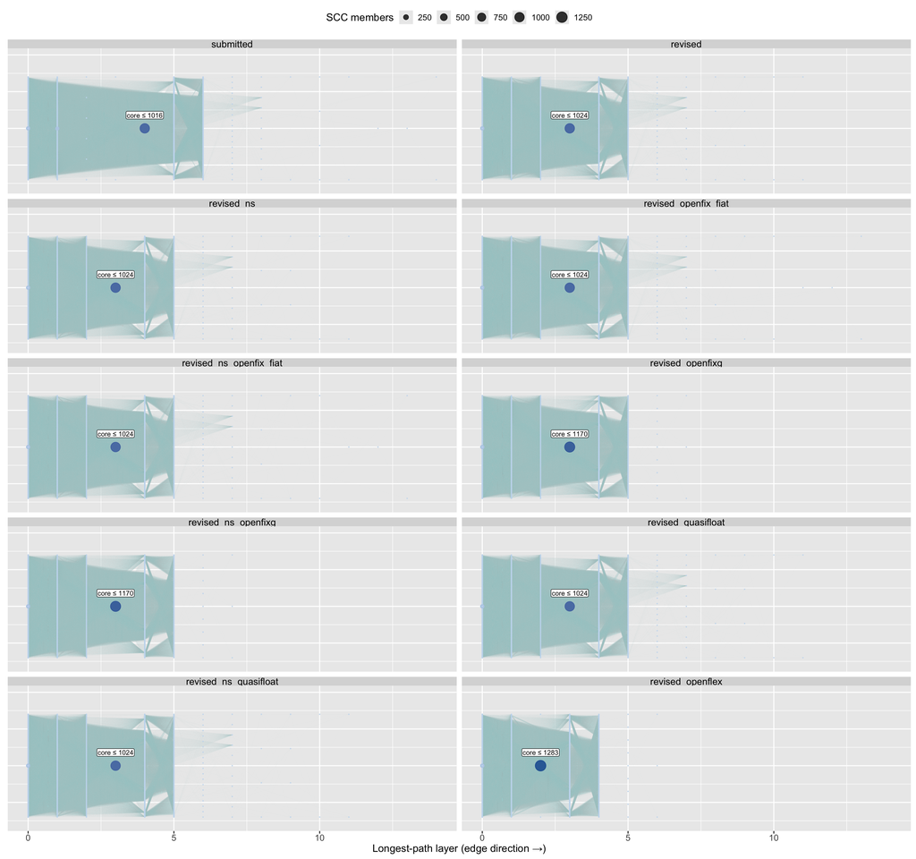

Sources: data/transition//dependency_graph.rds. Complete contemporaneous SCC condensation DAGs: one point per SCC and one line per distinct component-to-component edge. Every line goes from a lower to a higher longest-path layer. Vertical placement is a layout choice. Point size and the panel label give SCC membership count.

Sources: data/transition//convergence_profile_t.rds. Start is the cached initial-variable seed with the legacy markup reconstruction; settling is within relative tolerance 1e-10 of the final fixed-sweep iterate, with output magnitudes floored at 1e-30. OPENFLEX records the final outer-clearing pass’s inner trajectory. Live rows vary over that baseline. This measures the seed and statement order, not SCC size or a proof of convergence to a fixed point.

| arm | t | sweeps | baseline_live | settled_by_first | settled_by_twentieth | moving_after_fiftieth | last_settling |
| --- | --- | --- | --- | --- | --- | --- | --- |
| revised | 100 | 130 | 2964 | 340 | 454 | 2439 | 130 |
| revised_ns | 100 | 130 | 2964 | 341 | 459 | 2420 | 130 |
| revised_openfix_fiat | 100 | 130 | 2964 | 340 | 454 | 2439 | 130 |
| revised_ns_openfix_fiat | 100 | 130 | 2964 | 341 | 459 | 2420 | 130 |
| revised_openfixg | 100 | 260 | 2965 | 341 | 455 | 2507 | 260 |
| revised_ns_openfixg | 100 | 260 | 2965 | 342 | 456 | 2508 | 260 |
| revised_quasifloat | 100 | 130 | 2969 | 233 | 457 | 2439 | 130 |
| revised_ns_quasifloat | 100 | 130 | 2969 | 233 | 462 | 2420 | 130 |
| revised_openflex | 10 | 130 | 2861 | 378 | 2812 | 2 | 106 |

## Leading transition eigenvalues

Sources: data/transition//transition_matrix_t.rds, named by the arm and period columns. Spectrum is on the local endogenous lagged support; outside count uses modulus >1+1e-6, unit count |modulus−1|<=1e-6. Minutes are the matrix-column build wall time, with four worker processes.

|  | arm | t | dimension | rho | n_out | n_unit | sweeps | eps | minutes |
| --- | --- | --- | --- | --- | --- | --- | --- | --- | --- |
| 11 | submitted | 30 | 588 | 1.021673047 | 2 | 105 | 130 | 1e-06 | 3.587964431 |
| 9 | revised | 10 | 809 | 1.000795918 | 2 | 210 | 130 | 1e-06 | 14.89168077 |
| 10 | revised | 100 | 809 | 1.000006694 | 1 | 318 | 130 | 1e-06 | 14.60815395 |
| 4 | revised_ns | 100 | 810 | 1.000000001 | 0 | 320 | 130 | 1e-06 | 5.255085035 |
| 5 | revised_openfix_fiat | 100 | 809 | 1.021673047 | 3 | 317 | 130 | 1e-06 | 5.125031586 |
| 1 | revised_ns_openfix_fiat | 100 | 809 | 1.021673047 | 2 | 318 | 130 | 1e-06 | 5.164576364 |
| 6 | revised_openfixg | 100 | 809 | 1.000004855 | 2 | 315 | 260 | 1e-06 | 17.42134169 |
| 2 | revised_ns_openfixg | 100 | 810 | 1.000000603 | 0 | 318 | 260 | 1e-06 | 17.75568186 |
| 8 | revised_quasifloat | 100 | 811 | 1.001583143 | 2 | 317 | 130 | 1e-06 | 5.131769315 |
| 3 | revised_ns_quasifloat | 100 | 812 | 1.000000003 | 0 | 319 | 130 | 1e-06 | 5.317096233 |
| 7 | revised_openflex | 10 | 811 | 1.327452093 | 7 | 207 | 130 | 1e-06 | 6.181265469 |

Sources: data/transition//transition_matrix_t.rds; leading five sorted by modulus. Cycle is 2π/|arg(lambda)| periods for complex modes. Loadings are sums by variable family of normalised absolute eigenvector entries in the relative state basis.

|  | arm | t | rank | real | imag | modulus | cycle | top_relative_loadings |
| --- | --- | --- | --- | --- | --- | --- | --- | --- |
| 201 | submitted | 30 | 1 | 1.021673047 | 0 | 1.021673047 | NA | b_cb 0.9839; b_cb_s_Z2 0.0151; b_s 0.0010; b_b 0.0000; b_s_Z1 0.0000 |
| 202 | submitted | 30 | 2 | 1.021591264 | 0 | 1.021591264 | NA | b_s 1.0000; b_b 0.0000; b_cb 0.0000; b_cb_s_Z2 0.0000; b_s_Z1 0.0000 |
| 203 | submitted | 30 | 3 | 1.000000058 | 0 | 1.000000058 | NA | b_cb 0.5906; dc 0.3965; co2_cum 0.0072; ken 0.0051; b_s 0.0005 |
| 204 | submitted | 30 | 4 | 1.000000011 | 0 | 1.000000011 | NA | dc 0.5888; b_cb 0.4021; co2_cum 0.0084; ken 0.0003; b_s 0.0003 |
| 205 | submitted | 30 | 5 | 1.000000002 | 0 | 1.000000002 | NA | b_cb 0.9992; b_s 0.0008; b_b 0.0000; b_cb_s_Z2 0.0000; b_s_Z1 0.0000 |
| 161 | revised | 10 | 1 | 1.000795918 | 0 | 1.000795918 | NA | va_index 1.0000; a_s 0.0000; b_b 0.0000; b_cb 0.0000; b_cb_s_Z2 0.0000 |
| 162 | revised | 10 | 2 | 1.00028294 | 0 | 1.00028294 | NA | va_index 1.0000; a_s 0.0000; b_b 0.0000; b_cb 0.0000; b_cb_s_Z2 0.0000 |
| 163 | revised | 10 | 3 | 1.000000001 | 0 | 1.000000001 | NA | was_j 0.7216; dc 0.1213; b_cb 0.0594; or 0.0376; b_s 0.0306 |
| 164 | revised | 10 | 4 | 1 | 0 | 1 | NA | was_j 1.0000; a_s 0.0000; b_b 0.0000; b_cb 0.0000; b_cb_s_Z2 0.0000 |
| 165 | revised | 10 | 5 | 1 | 0 | 1 | NA | dc 1.0000; a_s 0.0000; b_b 0.0000; b_cb 0.0000; b_cb_s_Z2 0.0000 |
| 181 | revised | 100 | 1 | 1.000006694 | 0 | 1.000006694 | NA | va_index 1.0000; a_s 0.0000; b_b 0.0000; b_cb 0.0000; b_cb_s_Z2 0.0000 |
| 182 | revised | 100 | 2 | 1.000000001 | 1.290070928e-09 | 1.000000001 | 4870418499 | b_cb 0.2818; dc 0.2377; was_j 0.2371; b_s 0.1408; or 0.0945 |
| 183 | revised | 100 | 3 | 1.000000001 | -1.290070928e-09 | 1.000000001 | 4870418499 | b_cb 0.2818; dc 0.2377; was_j 0.2371; b_s 0.1408; or 0.0945 |
| 184 | revised | 100 | 4 | 1 | 0 | 1 | NA | dc 0.5109; was_j 0.3235; b_cb 0.0692; or 0.0504; b_s 0.0344 |
| 185 | revised | 100 | 5 | 1 | 0 | 1 | NA | was_j 1.0000; a_s 0.0000; b_b 0.0000; b_cb 0.0000; b_cb_s_Z2 0.0000 |
| 61 | revised_ns | 100 | 1 | 1.000000001 | 2.127250422e-10 | 1.000000001 | NA | b_cb 0.5056; dc 0.1863; was_j 0.1775; b_s 0.0888; or 0.0375 |
| 62 | revised_ns | 100 | 2 | 1.000000001 | -2.127250422e-10 | 1.000000001 | NA | b_cb 0.5056; dc 0.1863; was_j 0.1775; b_s 0.0888; or 0.0375 |
| 63 | revised_ns | 100 | 3 | 1 | 0 | 1 | NA | was_j 1.0000; a_s 0.0000; b_b 0.0000; b_cb 0.0000; b_cb_s_Z1 0.0000 |
| 64 | revised_ns | 100 | 4 | 1 | 0 | 1 | NA | was_j 1.0000; a_s 0.0000; b_b 0.0000; b_cb 0.0000; b_cb_s_Z1 0.0000 |
| 65 | revised_ns | 100 | 5 | 1 | 0 | 1 | NA | dc 0.5103; was_j 0.4102; b_cb 0.0492; or 0.0098; b_s 0.0096 |
| 81 | revised_openfix_fiat | 100 | 1 | 1.021673047 | 0 | 1.021673047 | NA | b_cb_s_Z2 0.9282; b_cb 0.0441; b_s 0.0276; a_s 0.0000; b_b 0.0000 |
| 82 | revised_openfix_fiat | 100 | 2 | 1.021591264 | 0 | 1.021591264 | NA | b_s 1.0000; a_s 0.0000; b_b 0.0000; b_cb 0.0000; b_cb_s_Z2 0.0000 |
| 83 | revised_openfix_fiat | 100 | 3 | 1.000006663 | 0 | 1.000006663 | NA | va_index 1.0000; a_s 0.0000; b_b 0.0000; b_cb 0.0000; b_cb_s_Z2 0.0000 |
| 84 | revised_openfix_fiat | 100 | 4 | 1 | 0 | 1 | NA | dc 1.0000; a_s 0.0000; b_b 0.0000; b_cb 0.0000; b_cb_s_Z2 0.0000 |
| 85 | revised_openfix_fiat | 100 | 5 | 1 | 0 | 1 | NA | was_j 1.0000; a_s 0.0000; b_b 0.0000; b_cb 0.0000; b_cb_s_Z2 0.0000 |
| 1 | revised_ns_openfix_fiat | 100 | 1 | 1.021673047 | 0 | 1.021673047 | NA | b_s 1.0000; a_s 0.0000; b_b 0.0000; b_cb 0.0000; b_cb_s_Z1 0.0000 |
| 2 | revised_ns_openfix_fiat | 100 | 2 | 1.021591264 | 0 | 1.021591264 | NA | b_cb_s_Z1 0.8806; b_cb 0.0985; b_s 0.0209; a_s 0.0000; b_b 0.0000 |
| 3 | revised_ns_openfix_fiat | 100 | 3 | 1 | 8.447557416e-11 | 1 | NA | was_j 0.5505; dc 0.4388; co2_cum 0.0068; ken 0.0037; kmat 0.0002 |
| 4 | revised_ns_openfix_fiat | 100 | 4 | 1 | -8.447557416e-11 | 1 | NA | was_j 0.5505; dc 0.4388; co2_cum 0.0068; ken 0.0037; kmat 0.0002 |
| 5 | revised_ns_openfix_fiat | 100 | 5 | 1 | 0 | 1 | NA | was_j 1.0000; a_s 0.0000; b_b 0.0000; b_cb 0.0000; b_cb_s_Z1 0.0000 |
| 101 | revised_openfixg | 100 | 1 | 1.000004855 | 0 | 1.000004855 | NA | va_index 1.0000; a_s 0.0000; b_b 0.0000; b_cb 0.0000; b_cb_s_Z2 0.0000 |
| 102 | revised_openfixg | 100 | 2 | 1.000001314 | 0 | 1.000001314 | NA | was_j 0.5508; dc 0.4361; co2_cum 0.0116; ken 0.0006; lf 0.0003 |
| 103 | revised_openfixg | 100 | 3 | 1.000000053 | 0 | 1.000000053 | NA | was_j 0.5571; dc 0.4230; co2_cum 0.0110; ken 0.0081; kmat 0.0003 |
| 104 | revised_openfixg | 100 | 4 | 1 | 6.95517189e-10 | 1 | NA | was_j 0.5417; dc 0.4153; co2_cum 0.0108; b_cb 0.0102; ken 0.0087 |
| 105 | revised_openfixg | 100 | 5 | 1 | -6.95517189e-10 | 1 | NA | was_j 0.5417; dc 0.4153; co2_cum 0.0108; b_cb 0.0102; ken 0.0087 |
| 21 | revised_ns_openfixg | 100 | 1 | 1.000000603 | 0 | 1.000000603 | NA | was_j 0.5377; dc 0.4440; co2_cum 0.0117; ken 0.0053; b_cb 0.0003 |
| 22 | revised_ns_openfixg | 100 | 2 | 1 | 0 | 1 | NA | dc 1.0000; a_s 0.0000; b_b 0.0000; b_cb 0.0000; b_cb_s_Z1 0.0000 |
| 23 | revised_ns_openfixg | 100 | 3 | 1 | 0 | 1 | NA | was_j 1.0000; a_s 0.0000; b_b 0.0000; b_cb 0.0000; b_cb_s_Z1 0.0000 |
| 24 | revised_ns_openfixg | 100 | 4 | 1 | 0 | 1 | NA | was_j 1.0000; a_s 0.0000; b_b 0.0000; b_cb 0.0000; b_cb_s_Z1 0.0000 |
| 25 | revised_ns_openfixg | 100 | 5 | 1 | 0 | 1 | NA | or 0.6165; b_cb 0.1469; dc 0.1451; b_s 0.0905; was_j 0.0007 |
| 141 | revised_quasifloat | 100 | 1 | 1.001583143 | 0 | 1.001583143 | NA | was_j 0.3158; dc 0.1513; b_cb 0.1174; p 0.0861; cab 0.0643 |
| 142 | revised_quasifloat | 100 | 2 | 1.000006811 | 0 | 1.000006811 | NA | va_index 1.0000; a_s 0.0000; b_b 0.0000; b_cb 0.0000; b_cb_s_Z2 0.0000 |
| 143 | revised_quasifloat | 100 | 3 | 1.00000001 | 0 | 1.00000001 | NA | was_j 0.5155; dc 0.4625; co2_cum 0.0112; or 0.0055; ken 0.0051 |
| 144 | revised_quasifloat | 100 | 4 | 1 | 0 | 1 | NA | was_j 1.0000; a_s 0.0000; b_b 0.0000; b_cb 0.0000; b_cb_s_Z2 0.0000 |
| 145 | revised_quasifloat | 100 | 5 | 1 | 0 | 1 | NA | was_j 1.0000; a_s 0.0000; b_b 0.0000; b_cb 0.0000; b_cb_s_Z2 0.0000 |
| 41 | revised_ns_quasifloat | 100 | 1 | 1.000000003 | 0 | 1.000000003 | NA | dc 0.5241; was_j 0.4458; or 0.0175; co2_cum 0.0096; ken 0.0023 |
| 42 | revised_ns_quasifloat | 100 | 2 | 1.000000001 | 0 | 1.000000001 | NA | b_cb 0.7423; b_s 0.1285; or 0.0833; was_j 0.0270; dc 0.0182 |
| 43 | revised_ns_quasifloat | 100 | 3 | 1 | 0 | 1 | NA | was_j 0.3642; dc 0.3251; or 0.2694; b_cb 0.0236; b_s 0.0143 |
| 44 | revised_ns_quasifloat | 100 | 4 | 1 | 0 | 1 | NA | was_j 1.0000; a_s 0.0000; b_b 0.0000; b_cb 0.0000; b_cb_s_Z1 0.0000 |
| 45 | revised_ns_quasifloat | 100 | 5 | 1 | 0 | 1 | NA | or 0.5671; b_cb 0.1856; b_s 0.1139; was_j 0.1087; dc 0.0231 |
| 121 | revised_openflex | 10 | 1 | 0.7913576757 | 1.065777691 | 1.327452093 | 6.740878893 | p 0.2687; n_j 0.1234; pop_j 0.1234; x_star 0.1162; x 0.1162 |
| 122 | revised_openflex | 10 | 2 | 0.7913576757 | -1.065777691 | 1.327452093 | 6.740878893 | p 0.2687; n_j 0.1234; pop_j 0.1234; x_star 0.1162; x 0.1162 |
| 123 | revised_openflex | 10 | 3 | 1.160404431 | 0 | 1.160404431 | NA | p 0.2225; n_j 0.1199; pop_j 0.1199; x 0.1126; x_star 0.1126 |
| 124 | revised_openflex | 10 | 4 | 1.021591264 | 0 | 1.021591264 | NA | b_s 1.0000; a_s 0.0000; b_b 0.0000; b_cb 0.0000; b_cb_s_Z2 0.0000 |
| 125 | revised_openflex | 10 | 5 | 1.002697581 | 0 | 1.002697581 | NA | va_index 1.0000; a_s 0.0000; b_b 0.0000; b_cb 0.0000; b_cb_s_Z2 0.0000 |

The family labels in these tables are engine row names: `dc` is the stock of durable consumption goods, `b_cb` central-bank bill holdings, `b_s` government bills, `p` sector producer prices, `cab` the current-account balance, `or` gold, and `b_cb_s_Z2`/`b_cb_s_Z1` the cross-region reserve bills. `n_j` and `pop_j` are sector employment and population rows; `x` is output and `x_star = pr × pop_j` is potential output, which enters the lagged output-gap price term. Definitions are in `model/code/MVP_model_2026.R` and each baseline’s `initial$vars` label/name table. A family loading sums normalised absolute entries and can conceal opposite signs; it does not identify an admissible accounting-consistent impulse.

## The spectrum that can feed activity and settlement

The full spectrum includes strictly downstream reporting modes. In the canonical gold cell, the value-added index is one such mode: its own lag multiplies by the current volume-growth factor, but its level never feeds production or financial settlement. Its multiplicative root can slightly exceed unity along a growing baseline without destabilising the economy.

`R/dynamics/export_feedback_spectrum.R` forms the graph with both contemporaneous and lagged edges and retains lagged state inputs that can reach regional VA, government bills, spending, gold, xr or official foreign reserves. Removing other coordinates is a block-triangular restriction: the retained rows have no structural input from removed variables. The graph is conservative, so it may retain inactive paths; it cannot remove a path resolved by the parser. This still includes autonomous and accounting-residue directions and is not a projection onto the stock-flow consistency manifold.

Sources: data/transition//transition_matrix_t.rds together with data/transition//dependency_graph.rds. States retained by structural reachability to the named activity/settlement anchors; removed is the strictly downstream state count. Unit and outside tolerances are as in the full spectrum.

|  | arm | t | dimension | removed | rho | n_out | n_unit |
| --- | --- | --- | --- | --- | --- | --- | --- |
| 11 | submitted | 30 | 476 | 112 | 1.021673047 | 2 | 101 |
| 9 | revised | 10 | 703 | 106 | 1.000000001 | 0 | 108 |
| 10 | revised | 100 | 703 | 106 | 1.000000001 | 0 | 216 |
| 4 | revised_ns | 100 | 704 | 106 | 1.000000002 | 0 | 217 |
| 5 | revised_openfix_fiat | 100 | 703 | 106 | 1.021673047 | 2 | 215 |
| 1 | revised_ns_openfix_fiat | 100 | 703 | 106 | 1.021673047 | 2 | 215 |
| 6 | revised_openfixg | 100 | 703 | 106 | 1.000001314 | 1 | 213 |
| 2 | revised_ns_openfixg | 100 | 704 | 106 | 1.000000603 | 0 | 216 |
| 8 | revised_quasifloat | 100 | 705 | 106 | 1.001583143 | 1 | 215 |
| 3 | revised_ns_quasifloat | 100 | 706 | 106 | 1.000000003 | 0 | 216 |
| 7 | revised_openflex | 10 | 705 | 106 | 1.327452093 | 5 | 105 |

Sources: data/transition//transition_matrix_t.rds and corresponding feedback_spectrum_t.rds. Leading activity/settlement modes, with normalised absolute relative-coordinate eigenvector mass by variable family. Imaginary parts below 1e-6 are treated as numerical real-mode splitting for the cycle column.

|  | arm | t | rank | real | imag | modulus | cycle | top_relative_loadings |
| --- | --- | --- | --- | --- | --- | --- | --- | --- |
| 201 | submitted | 30 | 1 | 1.021673047 | 0 | 1.021673047 | NA | b_cb 0.9839; b_cb_s_Z2 0.0151; b_s 0.0010; b_b 0.0000; b_s_Z1 0.0000 |
| 202 | submitted | 30 | 2 | 1.021591264 | 0 | 1.021591264 | NA | b_s 1.0000; b_b 0.0000; b_cb 0.0000; b_cb_s_Z2 0.0000; b_s_Z1 0.0000 |
| 203 | submitted | 30 | 3 | 1.000000058 | 0 | 1.000000058 | NA | b_cb 0.5978; dc 0.4017; b_s 0.0005; lh 0.0000; x_star 0.0000 |
| 161 | revised | 10 | 1 | 1.000000001 | 1.414483583e-09 | 1.000000001 | NA | dc 0.5270; b_cb 0.2423; b_s 0.1248; or 0.1059; lf 0.0000 |
| 162 | revised | 10 | 2 | 1.000000001 | -1.414483583e-09 | 1.000000001 | NA | dc 0.5270; b_cb 0.2423; b_s 0.1248; or 0.1059; lf 0.0000 |
| 163 | revised | 10 | 3 | 1 | 0 | 1 | NA | dc 1.0000; a_s 0.0000; b_b 0.0000; b_cb 0.0000; b_cb_s_Z2 0.0000 |
| 181 | revised | 100 | 1 | 1.000000001 | 0 | 1.000000001 | NA | b_cb 0.3971; dc 0.3219; b_s 0.1983; or 0.0828; lf 0.0000 |
| 182 | revised | 100 | 2 | 1 | 0 | 1 | NA | dc 0.4324; or 0.2626; b_cb 0.2037; b_s 0.1013; lh 0.0000 |
| 183 | revised | 100 | 3 | 1 | 0 | 1 | NA | or 0.3767; dc 0.3548; b_cb 0.1794; b_s 0.0891; lh 0.0000 |
| 61 | revised_ns | 100 | 1 | 1.000000002 | 0 | 1.000000002 | NA | b_cb 0.6406; dc 0.2003; b_s 0.1127; or 0.0463; lf 0.0000 |
| 62 | revised_ns | 100 | 2 | 1.000000001 | 0 | 1.000000001 | NA | b_cb 0.6860; dc 0.1395; b_s 0.1203; or 0.0542; lf 0.0000 |
| 63 | revised_ns | 100 | 3 | 1 | 0 | 1 | NA | dc 0.9984; b_cb 0.0012; b_s 0.0002; or 0.0002; lf 0.0000 |
| 81 | revised_openfix_fiat | 100 | 1 | 1.021673047 | 0 | 1.021673047 | NA | b_cb_s_Z2 0.9282; b_cb 0.0441; b_s 0.0276; a_s 0.0000; b_b 0.0000 |
| 82 | revised_openfix_fiat | 100 | 2 | 1.021591264 | 0 | 1.021591264 | NA | b_s 1.0000; a_s 0.0000; b_b 0.0000; b_cb 0.0000; b_cb_s_Z2 0.0000 |
| 83 | revised_openfix_fiat | 100 | 3 | 1 | 0 | 1 | NA | dc 1.0000; a_s 0.0000; b_b 0.0000; b_cb 0.0000; b_cb_s_Z2 0.0000 |
| 1 | revised_ns_openfix_fiat | 100 | 1 | 1.021673047 | 0 | 1.021673047 | NA | b_s 1.0000; a_s 0.0000; b_b 0.0000; b_cb 0.0000; b_cb_s_Z1 0.0000 |
| 2 | revised_ns_openfix_fiat | 100 | 2 | 1.021591264 | 0 | 1.021591264 | NA | b_cb_s_Z1 0.8806; b_cb 0.0985; b_s 0.0209; a_s 0.0000; b_b 0.0000 |
| 3 | revised_ns_openfix_fiat | 100 | 3 | 1 | 0 | 1 | NA | dc 1.0000; b_cb 0.0000; b_s 0.0000; lf 0.0000; b_cb_s_Z1 0.0000 |
| 101 | revised_openfixg | 100 | 1 | 1.000001314 | 0 | 1.000001314 | NA | dc 0.9983; lf 0.0007; b_cb 0.0003; n_j 0.0002; x 0.0002 |
| 102 | revised_openfixg | 100 | 2 | 1.000000053 | 0 | 1.000000053 | NA | dc 0.9990; b_cb 0.0004; or 0.0002; b_s 0.0002; lf 0.0002 |
| 103 | revised_openfixg | 100 | 3 | 1 | 6.955066533e-10 | 1 | NA | dc 0.9487; b_cb 0.0234; or 0.0159; b_s 0.0120; lf 0.0000 |
| 21 | revised_ns_openfixg | 100 | 1 | 1.000000603 | 0 | 1.000000603 | NA | dc 0.9976; b_cb 0.0007; or 0.0006; lf 0.0006; b_s 0.0002 |
| 22 | revised_ns_openfixg | 100 | 2 | 1 | 0 | 1 | NA | dc 1.0000; a_s 0.0000; b_b 0.0000; b_cb 0.0000; b_cb_s_Z1 0.0000 |
| 23 | revised_ns_openfixg | 100 | 3 | 1 | 0 | 1 | NA | or 0.6171; b_cb 0.1471; dc 0.1452; b_s 0.0906; lh 0.0000 |
| 141 | revised_quasifloat | 100 | 1 | 1.001583143 | 0 | 1.001583143 | NA | dc 0.2238; b_cb 0.1737; p 0.1274; cab 0.0951; b_s 0.0884 |
| 142 | revised_quasifloat | 100 | 2 | 1.00000001 | 0 | 1.00000001 | NA | dc 0.9881; or 0.0117; b_cb 0.0001; b_s 0.0001; lf 0.0000 |
| 143 | revised_quasifloat | 100 | 3 | 1 | 0 | 1 | NA | dc 1.0000; a_s 0.0000; b_b 0.0000; b_cb 0.0000; b_cb_s_Z2 0.0000 |
| 41 | revised_ns_quasifloat | 100 | 1 | 1.000000003 | 0 | 1.000000003 | NA | dc 0.9668; or 0.0322; b_cb 0.0009; b_s 0.0002; lh 0.0000 |
| 42 | revised_ns_quasifloat | 100 | 2 | 1.000000001 | 0 | 1.000000001 | NA | b_cb 0.7677; b_s 0.1328; or 0.0831; dc 0.0164; lh 0.0000 |
| 43 | revised_ns_quasifloat | 100 | 3 | 1 | 0 | 1 | NA | dc 0.4800; or 0.4550; b_cb 0.0403; b_s 0.0247; lh 0.0000 |
| 121 | revised_openflex | 10 | 1 | 0.7913576757 | 1.065777691 | 1.327452093 | 6.740878893 | p 0.2736; n_j 0.1256; pop_j 0.1256; x_star 0.1183; x 0.1183 |
| 122 | revised_openflex | 10 | 2 | 0.7913576757 | -1.065777691 | 1.327452093 | 6.740878893 | p 0.2736; n_j 0.1256; pop_j 0.1256; x_star 0.1183; x 0.1183 |
| 123 | revised_openflex | 10 | 3 | 1.160404431 | 0 | 1.160404431 | NA | p 0.2470; n_j 0.1331; pop_j 0.1331; x 0.1251; x_star 0.1251 |

The gold cells have no root outside the stated tolerance in the activity/settlement restriction. Both OPENFIXG cells retain neutral directions, but the doubled-sweep EU/RoW estimate also produces a leading root just outside that tolerance; its classification changed from the first build. This means the proposed claim that OPENFIXG leaves “none” needs qualification: its spending adjustment does not remove every neutral policy, accounting or stock direction. Neither result establishes attraction to a unique equilibrium or semisimplicity of its unit roots. The full-spectrum gold roots above unity load on the downstream value-added index and are retained in the separate full table. The OPENFIXG leading vectors are dominated by durable consumption stocks, and their near-unit classification is unresolved at this precision rather than evidence of a measured spending-adjustment instability. The first/final spectral comparison above exposes that sensitivity. These statements use `data/transition/{revised,revised_ns,revised_openfixg,revised_ns_openfixg}/feedback_summary_t100.csv` and the corresponding leading-vector files.

The existing EU/RoW quasi-float settings leave a growing feedback mode; North/South has no root outside the stated tolerance. Its loadings mix durable consumption stocks, central-bank holdings, prices, current accounts and bill stocks; it cannot be described solely as an exchange-rate root. The comparison is conditional on the closure row of `data/arms.csv` and the `par_xr` in the cached workbooks; this analysis does not choose a replacement. Sources are the two quasi-float `feedback_summary_t100.csv` and `feedback_eigenvalues_t100.csv` files. The exact workbook-specific multipliers and relative loadings are in the tables above.

## The fiat reserve-interest mode is measured directly

Source: data/transition/fiat_reserve_root_comparison_20261001.csv, computed from data/transition//transition_matrix_t100.rds and output/scenarios/arms//runs/baseline.RDS. Among roots outside the unit circle, select the mode with largest normalised absolute relative-coordinate mass on the active foreign reserve row; compare its real part with 1 plus the issuer’s baseline bill rate at t=100.

| arm | t | reserve | issuer | root_real | root_imag | reserve_relative_mass | issuer_bill_multiplier | root_minus_issuer_multiplier |
| --- | --- | --- | --- | --- | --- | --- | --- | --- |
| revised_openfix_fiat | 100 | Z1_b_cb_s_Z2 | Z2 | 1.021673047 | 0 | 0.9282380032 | 1.021673047 | 7.723555129e-11 |
| revised_ns_openfix_fiat | 100 | Z2_b_cb_s_Z1 | Z1 | 1.021591264 | 0 | 0.8806036478 | 1.021591264 | -8.078182567e-11 |

The reserve-loaded mode matches the issuer’s bill-interest multiplier on both workbooks. On North/South it is the second-ranked growing mode, so using only the spectral radius would attach the wrong bill rate to the reserve channel. The other growing bill-stock direction needs the accounting-manifold qualification discussed below. The sign of the baseline reserve position does not change the positive marginal multiplier; accepting the South’s short reserve remains a separate maintainer decision.

The isolated reserve equation also clarifies calibration: if a stationary reserve level is nonzero, the non-interest external flow must offset its interest flow. A zero total current account need not mean a zero non-interest current account. The finite-window stationarity criteria in `R/closures/closure_baseline_stability.R` do not prove an exact fixed point.

## Reading roots together with the closure

A root inside the unit circle decays locally; a root outside grows locally; a semisimple unit root preserves a level displacement. Defective unit roots can instead generate polynomial growth; semisimplicity is not established by the unit-root count. The full state also contains accounting identities, ecological accumulators, population stocks and prescribed policy levels. A unit root in those directions is not evidence that external adjustment failed, and a direction that violates the stock-flow accounting manifold cannot automatically be interpreted as an admissible economic disturbance. Conversely a stationary calibration does not establish attraction.

Under gold, the impulse’s lasting gold/debt displacement motivates looking for a neutral financial level direction. Under fiat, the reserve-interest recursion motivates looking for a reserve-carrying root near the bill-interest multiplier. Under OPENFIXG, adjustment is in the reserve holder’s real government spending; the external imbalance mode may decay even while autonomous or downstream state directions retain units. Under the quasi-float, the exchange rate and lagged trade response are part of the mode; the registry’s existing `par_xr` is measured rather than chosen.

The submitted official-sector circuit should be compared with revised financial loadings rather than with an unqualified unstable-root count. The table reports the full local spectrum’s count, and the leading-vector table identifies the variable families carrying the corresponding directions. It does not claim that every unstable direction lies on the consistency manifold.

For OPENFLEX the leading feedback pair is complex and growing, followed by a growing real mode: the table provides the measured moduli and local cycle. Its eigenvector mixes prices, employment/population and trade quantities. This is a coupled local mode rather than an isolated xr recursion.

For OPENFLEX, the period-ten measurement is a local derivative along a drifting baseline, not a stationary-point stability test. The scan’s growth of |xr−1| is a fitted trajectory slope, not an eigenvalue at period ten. Its multiplier is the exponential of that slope. In addition, the scan’s zero-portfolio-sensitivity runs have different settings from the registry’s full-sensitivity arm measured here; an anticipated root from those runs is not a numerical acceptance target for this arm.

## What this changes when reading the scenarios

For gold, report both flow responses and the lasting settlement-stock displacement: a current account that recedes need not restore the original gold or debt level. For fiat, an external reserve displacement can be carried forward by interest, so a finite endpoint is not a long-run equilibrium effect. OPENFIXG adjusts the reserve holder’s government spending, so a scenario can move real demand through its settlement rule. Its near-unit stock directions remain sensitive to numerical precision, so this measurement neither proves nor rules out a growing economic adjustment mode. EU/RoW QUASIFLOAT’s slow growing mode makes a quiet finite window insufficient evidence of long-run absorption; the North/South result shows why this cannot be generalised across workbooks.

The evidence for those scenario-reading implications is the local spectrum above together with `output/calibration/closure_impulse_20261001.csv` (shock-minus-baseline paths of the named stocks and flows). The scenario comparison itself remains the period-90 shock-minus-baseline measurement in `output/calibration/transmission_regimes_revised_20261001.csv`; these endpoint matrices do not decompose or replace those finite scenario effects. OPENFLEX’s drifting diagnostic point supplies no valid stationary scenario comparator.

## Limits and maintainer decisions

The lagged technology matrix is held at its baseline value in these derivatives. On an unshocked baseline the circular target equals the initial technology; this does not measure a scenario’s changing technology schedule or add its technology-coefficient dynamics to the state. The state support is local and coefficients can activate elsewhere. The matrices describe fixed parameters and small deviations; they do not establish global stability or select a closure for publication.

The submitted reference is at a different period from the ready-cell endpoint. The extra canonical period-ten measurement helps distinguish period effects, but one cannot infer that every difference is a closure effect: specification, workbook calibration and initial stocks also differ. The graph’s upper and lower bounds retain their distinct definitions, and solver settling times are not SCC sizes.

Scenario 6, `par_xr`, the South’s short fiat reserve, and recalibration of the canonical enterprise premium with Ξ remain the maintainer’s decisions. No value or intervention is changed here.

**Sources:** all matrix, graph, support, derivative-check and spectrum files named above; `output/calibration/dynamics_cells_20261001.log`; the four ported scripts and shared context; `model/code/sraffian_block_2026.R` (pure price functions); `model/code/MVP_model_2026.R`; `model/code/run_model_2026.R`; `data/arms.csv`; the submitted reports `qmd/reports/2026-09-09-dynamical-form.qmd` and `qmd/reports/2026-09-10-regime-structure.qmd`; `log/trackers/closure_region.md`.